#### トップページに戻る

# Pandas―データ分析（５）応用：都道府県別人口推移

# 「分離ー適用ー結合」の一例

国勢調査をもとにした人口推移のCSVを使います。  
このデータの中には、都道府県別の人口推移があるので、pandasで解析してみましょう。  
とりあえず

- 都道府県別の人口増減を一次近似で求め、その勾配ランキングを作る

という目的でやってみましょう。  
データは[政府統計の総合窓口(e-Stat)](https://www.e-stat.go.jp/stat-search/files?page=1&layout=datalist&toukei=00200521&tstat=000001011777&cycle=0&tclass1=000001094741)からもらってきました。

```python
# 慣習、下の２つはよく使うからインポートしておく
import pandas as pd

%matplotlib inline
import matplotlib.pyplot as plt
import numpy as np
```

```python
# 最初の５行を出力
with open("c01.csv", "r", encoding="shift-jis") as fp:
    for line in fp.readlines()[:5]:
        print(line.strip())
```

```
"都道府県コード","都道府県名","元号","和暦（年）","西暦（年）","注","人口（総数）","人口（男）","人口（女）"
"00","全国","大正",9,1920,"",55963053,28044185,27918868
"01","北海道","大正",9,1920,"",2359183,1244322,1114861
"02","青森県","大正",9,1920,"",756454,381293,375161
"03","岩手県","大正",9,1920,"",845540,421069,424471
```

pandasだとcsvを一行で読み込むことが出来ます（エンコードは適当に探す）

```python
# 一行でcsvファイルをDataFrameに変換できる
df = pd.read_csv("c01.csv", encoding="shift-jis", skipfooter=2, engine="python")
df = df.rename(columns={"人口（総数）": "全人口", "人口（男）": "男", "人口（女）": "女"})

# 最初の５行
df.head()
```

|  | 都道府県コード | 都道府県名 | 元号 | 和暦（年） | 西暦（年） | 注 | 全人口 | 男 | 女 |
| --- | --- | --- | --- | --- | --- | --- | --- | --- | --- |
| 0 | 00 | 全国 | 大正 | 9 | 1920 | NaN | 55963053 | 28044185 | 27918868 |
| 1 | 01 | 北海道 | 大正 | 9 | 1920 | NaN | 2359183 | 1244322 | 1114861 |
| 2 | 02 | 青森県 | 大正 | 9 | 1920 | NaN | 756454 | 381293 | 375161 |
| 3 | 03 | 岩手県 | 大正 | 9 | 1920 | NaN | 845540 | 421069 | 424471 |
| 4 | 04 | 宮城県 | 大正 | 9 | 1920 | NaN | 961768 | 485309 | 476459 |

```python
# 最後の５行
df.tail()
```

|  | 都道府県コード | 都道府県名 | 元号 | 和暦（年） | 西暦（年） | 注 | 全人口 | 男 | 女 |
| --- | --- | --- | --- | --- | --- | --- | --- | --- | --- |
| 975 | 43 | 熊本県 | 平成 | 27 | 2015 | NaN | 1786170 | 841046 | 945124 |
| 976 | 44 | 大分県 | 平成 | 27 | 2015 | NaN | 1166338 | 551932 | 614406 |
| 977 | 45 | 宮崎県 | 平成 | 27 | 2015 | NaN | 1104069 | 519242 | 584827 |
| 978 | 46 | 鹿児島県 | 平成 | 27 | 2015 | NaN | 1648177 | 773061 | 875116 |
| 979 | 47 | 沖縄県 | 平成 | 27 | 2015 | NaN | 1433566 | 704619 | 728947 |

```python
# dfのSeriesを確認
df.columns
```

```
Index(['都道府県コード', '都道府県名', '元号', '和暦（年）', '西暦（年）', '注', '全人口', '男', '女'], dtype='object')
```

```python
# 各Seriesのdtypeの確認
df.dtypes
```

```
都道府県コード    object
都道府県名      object
元号         object
和暦（年）       int64
西暦（年）       int64
注          object
全人口        object
男          object
女          object
dtype: object
```

```python
# 人口を数値データに変換
for col in ["全人口", "男", "女"]:
    df[col] = pd.to_numeric(df[col], errors="coerce")
```

pd.to_numeric?をみると

> Signature: pd.to_numeric(arg, errors='raise')

> errors : {'ignore', 'raise', 'coerce'}, default 'raise'
> - If 'raise', then invalid parsing will raise an exception
> - If 'coerce', then invalid parsing will be set as NaN
>   - If 'ignore', then invalid parsing will return the input

errors="coerce"とキーワード引数を与えてやれば、キャストできないものを欠損値として置き換えてくれるそうです。  
デフォルトではエラーを吐き出すという設定になっていますね。

```python
df.dtypes
```

```
都道府県コード     object
都道府県名       object
元号          object
和暦（年）        int64
西暦（年）        int64
注           object
全人口        float64
男          float64
女          float64
dtype: object
```

```python
# 組み込み関数のset()と似た働き
df["都道府県名"].unique()
```

```
array(['全国', '北海道', '青森県', '岩手県', '宮城県', '秋田県', '山形県', '福島県', '茨城県',
       '栃木県', '群馬県', '埼玉県', '千葉県', '東京都', '神奈川県', '新潟県', '富山県', '石川県',
       '福井県', '山梨県', '長野県', '岐阜県', '静岡県', '愛知県', '三重県', '滋賀県', '京都府',
       '大阪府', '兵庫県', '奈良県', '和歌山県', '鳥取県', '島根県', '岡山県', '広島県', '山口県',
       '徳島県', '香川県', '愛媛県', '高知県', '福岡県', '佐賀県', '長崎県', '熊本県', '大分県',
       '宮崎県', '鹿児島県', '沖縄県', '人口集中地区', '人口集中地区以外の地区'], dtype=object)
```

```python
# 都道府県の行だけを抽出する
df = df[df["都道府県名"].isin(df["都道府県名"].unique()[1:-2])]
```

さて、解析のための準備が整いました。  
都道府県名をkeyにしてgroupbyし、その勾配を求める自作関数を作れば良さそうです。  
indexはこれから時系列として扱うので西暦に変更しておきます。

```python
df.index = df['西暦（年）']
```

試しに各都道府県の人口推移をプロットしてみます。

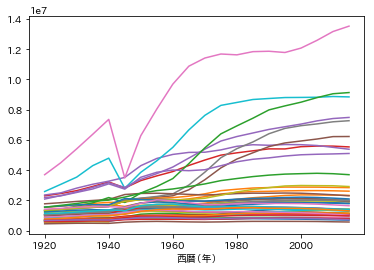

```python
df.groupby("都道府県名")["全人口"].plot(x="西暦")
plt.show()
```

さて、このDataFrameから人口増減勾配を求める方法を考えましょう。
そのような方法はたくさんありますが今回は擬似逆行列を使って素早く求めましょう。
$$d=Gm$$ のとき$、G^\dagger$を擬似逆行列とすると $$m=G^\dagger d$$ となります。

```python
# Seriesを受け取って、勾配を返す関数
def calc_slope(sr):

    # 欠損値を取り除く
    sr = sr.dropna()

    # x軸として年を取る
    x = sr.index.values

    # Green関数（直線なのでパラメータ２つ）
    G = np.vstack((x, np.ones_like(x))).T
    d = sr.values

    # 直線のパラメータ
    params = np.linalg.pinv(G) @ d

    # 勾配のみを返す
    return params[0]
```

```python
increase_rate = df.groupby("都道府県名")[["全人口", "男", "女"]].agg(calc_slope)
increase_rate.head()
```

| 都道府県名 | 全人口 | 男 | 女 |
| --- | --- | --- | --- |
| 三重県 | 9100.340752 | 4410.786917 | 4689.553835 |
| 京都府 | 15529.986617 | 7108.792782 | 8421.193835 |
| 佐賀県 | 1806.813083 | 722.221805 | 1084.591278 |
| 兵庫県 | 39889.076992 | 18437.361504 | 21451.715489 |
| 北海道 | 36862.745263 | 15877.846165 | 20984.899098 |

ようやく、都道府県ごと、ついでに性別別の人口推移勾配が求まりました。

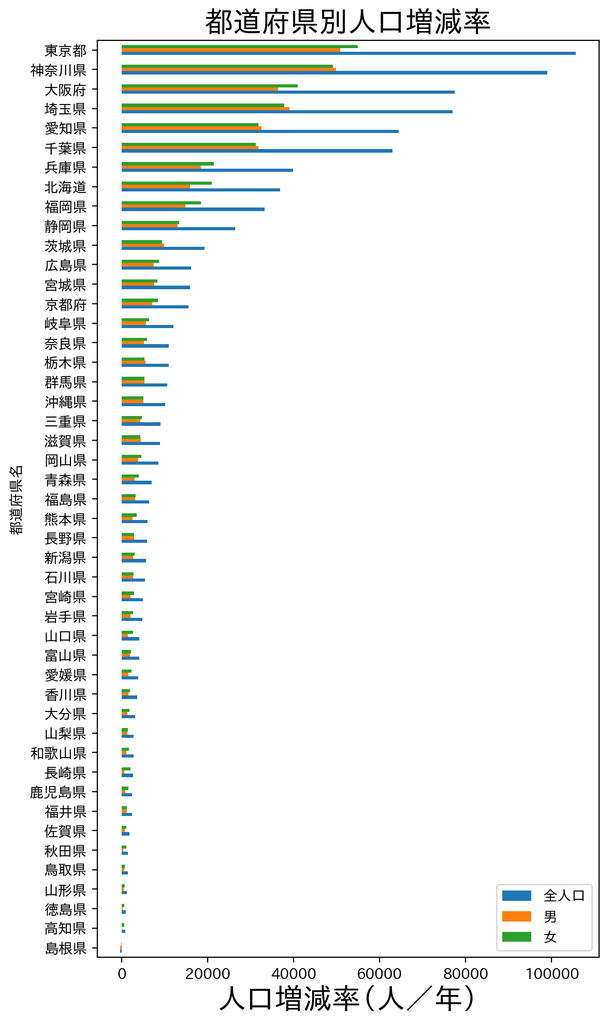

```python
fig, ax = plt.subplots(figsize=(6, 10), dpi=200)
increase_rate.sort_values("全人口").plot.barh(ax=ax)
plt.title("都道府県別人口増減率", fontsize=20)
plt.xlabel("人口増減率（人／年）", fontsize=20)
plt.tight_layout()
plt.show()
```

完成です。  
今回は都道府県別を調べましたが、データさえあれば、（コードをほとんど変えずに）市町村でもできることが分かってもらえると思います。  
このようにpandasには汎用性の高い機能がたくさんあり、それらを組み合わせる技術が問われていくのだろうと思います。

# もっとPandasを知りたい人へ

参考にしてほしい本として「[Pythonによるデータ分析入門](https://www.oreilly.co.jp/books/9784873116556/)（O'REILLY）」があります。  
これはPandasを作った人の本であり、（当然ながら）Pandasについてとても詳細に書かれています。  
読んだら当然理解できるはずですが、読まなくてもPandasを使いながらググったり、ドキュメントを読んでいると自然と必要な機能は分かってくると思います。

## 基礎編

Pythonの基礎（１）

Pythonの基礎（２）

Matplotlib

Numpyの基礎 ― 導入

Numpyの基礎 ― 生成関数

Numpyの基礎 ― 配列に関数を作用させる

Numpyの基礎 ― データ型（C,Fortranとの比較）

Numpyの基礎 ― 要素の取り出し方

Numpyの基礎 ― ブロードキャスト

Numpyの基礎 ― 線形代数やフーリエ変換

Numpyの基礎 ― 様々な形式に対応したファイル入出力

ファイル読み込み

文字列操作 ― 数値を文字列にフォーマットする

文字列操作 ― 文字列に関数を適用する

読みやすいPythonコードを書こう

## 応用編

Animation

Fortran, C言語 との連携

Pandas ― データ分析（１）時系列などをうまく扱えるようにする

Pandas ― データ分析（２）複数の列を持った表形式でデータを格納する

Pandas ― データ分析（３）データを分割し、個別に集計する

Pandas ― データ分析（４）高度なファイル入出力

Pandas ― データ分析（５）応用：都道府県別人口推移

Seaborn ― matplotlib をより美しく、使いやすく

shやBashの代わりにPythonを使う

SymPy ― 代数演算（１）文字を文字のまま計算する

SymPy ― 代数演算（２）応用：ラグランジアンから運動方程式を求めて二重振り子を解く

#### トップページに戻る